# Defense Services Ceiling Breaches

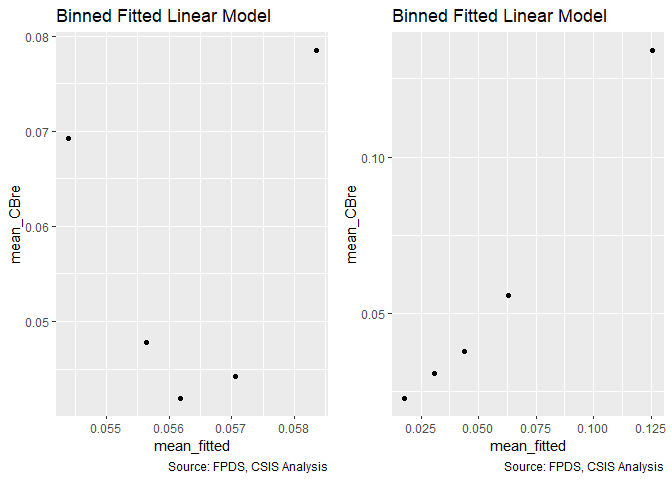

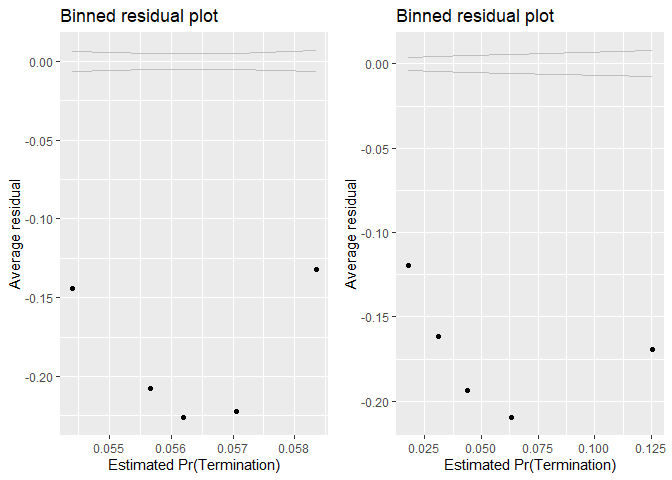

```
## [[1]]
##        model deviance null.deviance  difference
## 1 model1_old 108355.9      108365.4    9.509405
## 2 model1_new 101028.0      108365.4 7337.378561
##
## [[2]]
##                              GVIF Df GVIF^(1/(2*Df))
## cl_US6_avg_sal_lag1Const 1.661642  1        1.289047
## cl_CFTE                  1.315467  1        1.146938
## c_pPBSC                  1.395188  1        1.181181
## c_pOffPSC                1.849510  1        1.359967
## c_pairHist               1.299333  1        1.139883
## cl_pairCA                2.121995  1        1.456707
## cl_Ceil                  1.483606  1        1.218033
## capped_cl_Days           1.408622  1        1.186854
## Comp1or5                 1.254976  3        1.038578
## Veh                      1.809599  4        1.076956
## PricingUCA               1.206494  6        1.015766
## Crisis                   1.350487  3        1.051353
## cl_def6_HHI_lag1         2.052565  1        1.432677
## cl_def6_ratio_lag1       1.791530  1        1.338480
## cl_def3_HHI_lag1         1.917958  1        1.384904
## cl_def3_ratio_lag1       2.233038  1        1.494335
```

```r
summary_residual_compare(b_CBre09D2,b_CBre10D)
```

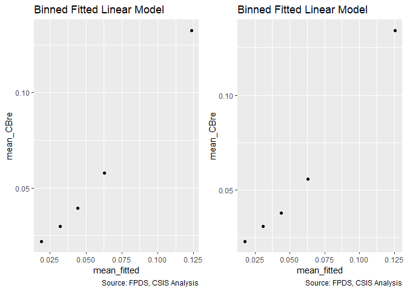

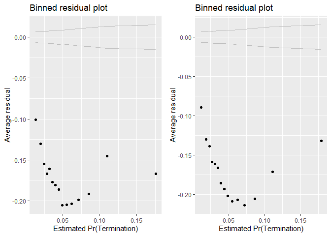

```
## [[1]]
##        model deviance null.deviance difference
## 1 model1_old 101427.9      108365.4   6937.475
## 2 model1_new 101028.0      108365.4   7337.379
##
## [[2]]
##                              GVIF Df GVIF^(1/(2*Df))
## cl_US6_avg_sal_lag1Const 1.661642  1        1.289047
## cl_CFTE                  1.315467  1        1.146938
## c_pPBSC                  1.395188  1        1.181181
## c_pOffPSC                1.849510  1        1.359967
## c_pairHist               1.299333  1        1.139883
## cl_pairCA                2.121995  1        1.456707
## cl_Ceil                  1.483606  1        1.218033
## capped_cl_Days           1.408622  1        1.186854
## Comp1or5                 1.254976  3        1.038578
## Veh                      1.809599  4        1.076956
## PricingUCA               1.206494  6        1.015766
## Crisis                   1.350487  3        1.051353
## cl_def6_HHI_lag1         2.052565  1        1.432677
## cl_def6_ratio_lag1       1.791530  1        1.338480
## cl_def3_HHI_lag1         1.917958  1        1.384904
## cl_def3_ratio_lag1       2.233038  1        1.494335
```

```r
summary_residual_compare(b_CBre08B,b_CBre10D)
```

HHI6 for ceiling breach now matches expectations but HHI6 for term went in the opposite direction. s

## Office

### Office and Vendor-Office Pair

#### Model 11A: Vendor Market Share

Expectation: Contracts of offices partnered with vendors who have larger market shares would be more likely to experience cost ceiling breaches and exercised options, but less likely to have terminations. Market Share Vendor for that Office c_pMarket ++ - +

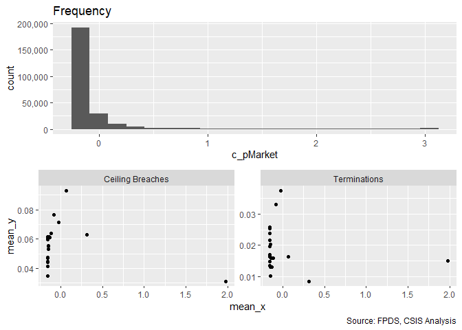

```r
summary_continuous_plot(serv_smp,"c_pMarket")
```

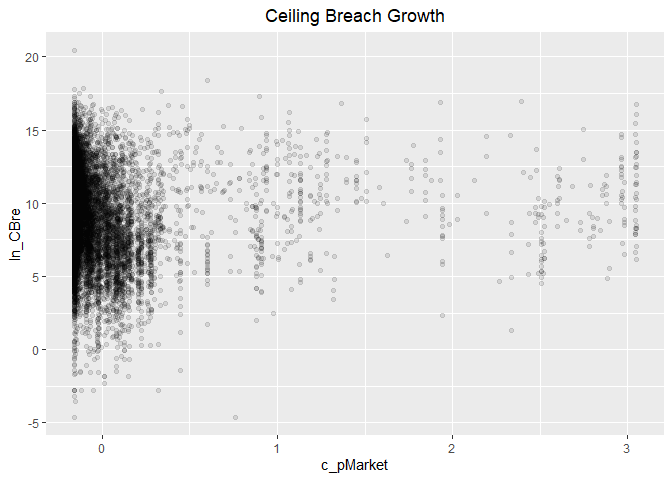

```r
#Scatter Plot
ggplot(serv_smp, aes(x=c_pMarket, y=ln_CBre)) + geom_point(alpha = 0.1) + ggtitle('Ceiling Breach Growth') + theme(plot.title = element_text(hjust = 0.5))
```

```r
#Model
b_CBre11A <- glm (data=serv_smp,
                 b_CBre ~ c_pMarket, family=binomial(link="logit"))
display(b_CBre11A)
```

```
## glm(formula = b_CBre ~ c_pMarket, family = binomial(link = "logit"),
##     data = serv_smp)
##             coef.est coef.se
## (Intercept) -2.82     0.01
## c_pMarket   -0.24     0.02
## ---
##   n = 250000, k = 2
##   residual deviance = 108228.0, null deviance = 108365.4 (difference = 137.3)
```

```r
n_CBre11A <- glm(data=serv_smp,
                        ln_CBre ~ c_pMarket)

display(n_CBre11A)
```

```
## glm(formula = ln_CBre ~ c_pMarket, data = serv_smp)
##             coef.est coef.se
## (Intercept)  9.25     0.02
## c_pMarket   -0.19     0.07
## ---
##   n = 15018, k = 2
##   residual deviance = 114504.9, null deviance = 114568.9 (difference = 64.0)
##   overdispersion parameter = 7.6
##   residual sd is sqrt(overdispersion) = 2.76
```

```r
#Plot residuals versus fitted
stargazer::stargazer(b_CBre11A,

                       n_CBre11A,
                       type="text",
                       digits=2)
```

```
##
## ==============================================
##                       Dependent variable:
##                   ----------------------------
##                       b_CBre        ln_CBre
##                      logistic       normal
##                        (1)            (2)
## ----------------------------------------------
## c_pMarket            -0.24***      -0.19***
##                       (0.02)        (0.07)
##
## Constant             -2.82***       9.25***
##                       (0.01)        (0.02)
##
## ----------------------------------------------
## Observations         250,000        15,018
## Log Likelihood      -54,114.01    -36,564.16
## Akaike Inf. Crit.   108,232.00     73,132.32
## ==============================================
## Note:              *p<0.1; **p<0.05; ***p<0.01
```

Aligns with expectations on terminatio, but not for ceiling breach or for options.

#### Model 11B: Cumulative Model

```r
#Frequency Plot for unlogged ceiling


#Model
b_CBre11B <- glm (data=serv_smp,
                 b_CBre ~  cl_US6_avg_sal_lag1Const +
                   cl_CFTE+ c_pPBSC+c_pOffPSC+
                 c_pairHist+cl_pairCA +
                   cl_Ceil + capped_cl_Days+
                   Comp1or5+
                   Veh+
                   PricingUCA+
                   Crisis+
                   cl_def6_HHI_lag1+cl_def6_ratio_lag1+
                   cl_def3_HHI_lag1+cl_def3_ratio_lag1+
                   c_pMarket, family=binomial(link="logit"))
glmer_examine(b_CBre11B)
```

```
##                              GVIF Df GVIF^(1/(2*Df))
## cl_US6_avg_sal_lag1Const 1.678529  1        1.295580
## cl_CFTE                  1.333478  1        1.154763
## c_pPBSC                  1.457100  1        1.207104
## c_pOffPSC                1.928739  1        1.388790
## c_pairHist               1.300134  1        1.140234
## cl_pairCA                2.264217  1        1.504731
## cl_Ceil                  1.509531  1        1.228630
## capped_cl_Days           1.411587  1        1.188102
## Comp1or5                 1.265587  3        1.040037
## Veh                      1.817847  4        1.077568
## PricingUCA               1.214642  6        1.016336
## Crisis                   1.342269  3        1.050284
## cl_def6_HHI_lag1         2.066067  1        1.437382
## cl_def6_ratio_lag1       1.867027  1        1.366392
## cl_def3_HHI_lag1         1.934690  1        1.390931
## cl_def3_ratio_lag1       2.307431  1        1.519023
## c_pMarket                1.270242  1        1.127050
```

```r
n_CBre11B <- glm(data=serv_smp,
                        ln_CBre ~  cl_US6_avg_sal_lag1Const +
                   cl_CFTE+ c_pPBSC+c_pOffPSC+
                 c_pairHist+cl_pairCA+
                 cl_Ceil + capped_cl_Days+
                 Comp1or5+
                   Veh+
                   PricingUCA+
                   Crisis+
                 cl_def6_HHI_lag1+cl_def6_ratio_lag1+
                 cl_def3_HHI_lag1+cl_def3_ratio_lag1+
                 c_pMarket)

glmer_examine(n_CBre11B)
```

```
##                              GVIF Df GVIF^(1/(2*Df))
## cl_US6_avg_sal_lag1Const 1.670829  1        1.292606
## cl_CFTE                  1.395725  1        1.181408
## c_pPBSC                  2.361696  1        1.536781
## c_pOffPSC                3.361654  1        1.833481
## c_pairHist               1.381271  1        1.175275
## cl_pairCA                2.807736  1        1.675630
## cl_Ceil                  1.967813  1        1.402788
## capped_cl_Days           1.625067  1        1.274781
## Comp1or5                 1.319198  3        1.047253
## Veh                      2.116268  4        1.098238
## PricingUCA               1.303780  6        1.022352
## Crisis                   1.257109  3        1.038872
## cl_def6_HHI_lag1         2.880586  1        1.697229
## cl_def6_ratio_lag1       1.646400  1        1.283121
## cl_def3_HHI_lag1         2.126115  1        1.458120
## cl_def3_ratio_lag1       2.076353  1        1.440956
## c_pMarket                1.320094  1        1.148954
```

```r
#Plot residuals versus fitted
stargazer::stargazer(b_CBre10D,b_CBre11A,b_CBre11B,

                     n_CBre10D,n_CBre11A,n_CBre11B,
                       type="text",
                       digits=2)
```

```
##
## ================================================================================================
##                                                       Dependent variable:
##                                -----------------------------------------------------------------
##                                             b_CBre                          ln_CBre
##                                            logistic                          normal
##                                   (1)        (2)        (3)        (4)        (5)        (6)
## ------------------------------------------------------------------------------------------------
## cl_US6_avg_sal_lag1Const        -0.07***              -0.10***    0.10**                0.11**
##                                  (0.02)                (0.03)     (0.05)                (0.05)
##
## cl_CFTE                          0.05**               0.07***    0.27***               0.26***
##                                  (0.02)                (0.02)     (0.04)                (0.04)
##
## c_pPBSC                         -0.18***              -0.24***   -0.27***              -0.26***
##                                  (0.02)                (0.02)     (0.04)                (0.04)
##
## c_pOffPSC                       0.97***               1.04***    -0.55***              -0.56***
##                                  (0.02)                (0.02)     (0.04)                (0.04)
##
## c_pairHist                      -0.07***              -0.06***    0.07**                0.07*
##                                  (0.02)                (0.02)     (0.04)                (0.04)
##
## cl_pairCA                        -0.02                0.13***     -0.09*               -0.14***
##                                  (0.03)                (0.03)     (0.05)                (0.05)
##
## cl_Ceil                         0.99***               1.03***    2.90***               2.89***
##                                  (0.02)                (0.02)     (0.04)                (0.04)
##
## capped_cl_Days                   0.05**                 0.03      0.10**                0.10**
##                                  (0.02)                (0.02)     (0.04)                (0.04)
##
## Comp1or51 offer                 -0.14***              -0.10***    -0.01                 -0.02
##                                  (0.03)                (0.03)     (0.06)                (0.06)
##
## Comp1or52-4 offers              0.31***               0.29***    -0.23***              -0.23***
##                                  (0.02)                (0.02)     (0.04)                (0.04)
##
## Comp1or55+ offers               0.37***               0.33***    -0.15***              -0.14***
##                                  (0.03)                (0.03)     (0.04)                (0.04)
```

[output cut: 49 more lines]

```
## cl_def3_ratio_lag1              -0.07***              -0.07**    0.37***               0.37***
##                                  (0.03)                (0.03)     (0.05)                (0.05)
##
## c_pMarket                                  -0.24***   -0.52***              -0.19***   0.15***
##                                             (0.02)     (0.03)                (0.07)     (0.05)
##
## Constant                        -2.96***   -2.82***   -2.97***   8.72***    9.25***    8.72***
##                                  (0.02)     (0.01)     (0.02)     (0.04)     (0.02)     (0.04)
##
## ------------------------------------------------------------------------------------------------
## Observations                    250,000    250,000    250,000     15,018     15,018     15,018
## Log Likelihood                 -50,513.99 -54,114.01 -50,316.53 -30,150.06 -36,564.16 -30,145.37
## Akaike Inf. Crit.              101,086.00 108,232.00 100,693.10 60,358.12  73,132.32  60,350.75
## ================================================================================================
## Note:                                                                *p<0.1; **p<0.05; ***p<0.01
```

```r
#summary_residual_compare(b_CBre10D,b_CBre11B)
#summary_residual_compare(b_CBre11A,b_CBre11B)
```

Note that the VIF is getting high on pair_CA.

### Other Office Characteristics

#### 12A: Past Office Volume (dollars)

Expectation: Contracting offices previously had more contract volume in dollars would have more experience managing cost and preventing cost-ceiling breaches, therefore larger past office volume would lower the likelihood of cost-ceiling breaches but no substantial relationships with likelihood of terminations or exercised options.

Past Office Volume $s cl_OffVol - + + From looking at data, terminations, easier for big, less dependent. - less dependenct

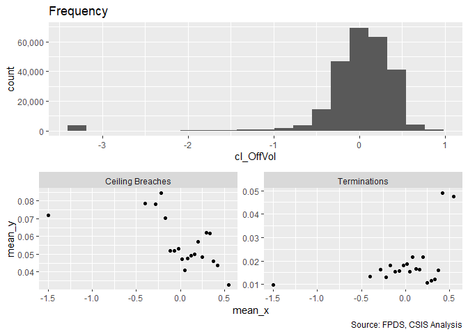

```r
summary_continuous_plot(serv_smp,"cl_OffVol")
```

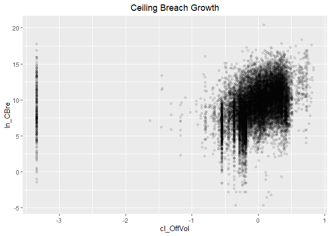

```r
#Scatter Plot
ggplot(serv_smp, aes(x=cl_OffVol, y=ln_CBre)) + geom_point(alpha = 0.1) + ggtitle('Ceiling Breach Growth') + theme(plot.title = element_text(hjust = 0.5))
```

```r
#Model
b_CBre12A <- glm (data=serv_smp,
                 b_CBre ~ cl_OffVol, family=binomial(link="logit"))
display(b_CBre12A)
```

```
## glm(formula = b_CBre ~ cl_OffVol, family = binomial(link = "logit"),
##     data = serv_smp)
##             coef.est coef.se
## (Intercept) -2.82     0.01
## cl_OffVol   -0.19     0.01
## ---
##   n = 250000, k = 2
##   residual deviance = 108214.9, null deviance = 108365.4 (difference = 150.4)
```

```r
n_CBre12A <- glm(data=serv_smp,
                        ln_CBre ~ cl_OffVol)

display(n_CBre12A)
```

```
## glm(formula = ln_CBre ~ cl_OffVol, data = serv_smp)
##             coef.est coef.se
## (Intercept) 9.33     0.02
## cl_OffVol   1.30     0.04
## ---
##   n = 15018, k = 2
##   residual deviance = 107472.4, null deviance = 114568.9 (difference = 7096.4)
##   overdispersion parameter = 7.2
##   residual sd is sqrt(overdispersion) = 2.68
```

```r
#Plot residuals versus fitted
stargazer::stargazer(b_CBre12A,

                       n_CBre12A,
                       type="text",
                       digits=2)
```

```
##
## ==============================================
##                       Dependent variable:
##                   ----------------------------
##                       b_CBre        ln_CBre
##                      logistic       normal
##                        (1)            (2)
## ----------------------------------------------
## cl_OffVol            -0.19***       1.30***
##                       (0.01)        (0.04)
##
## Constant             -2.82***       9.33***
##                       (0.01)        (0.02)
##
## ----------------------------------------------
## Observations         250,000        15,018
## Log Likelihood      -54,107.46    -36,088.22
## Akaike Inf. Crit.   108,218.90     72,180.43
## ==============================================
## Note:              *p<0.1; **p<0.05; ***p<0.01
```

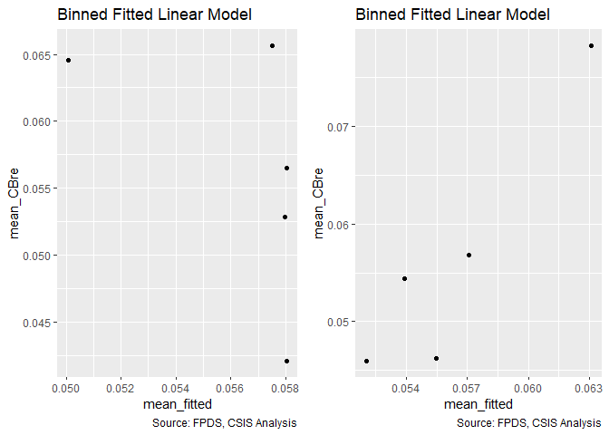

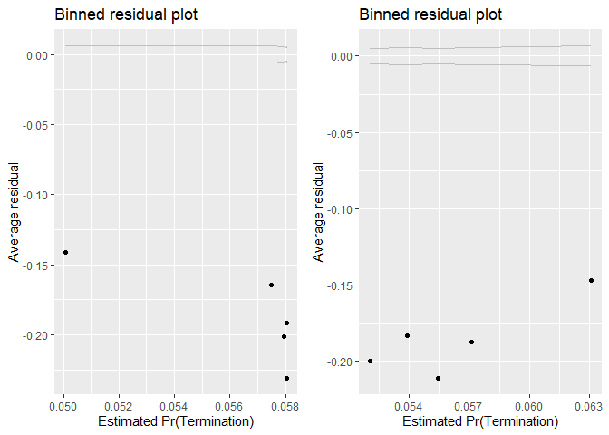

```r
summary_residual_compare(b_CBre11A,b_CBre12A, skip_vif = TRUE)
```

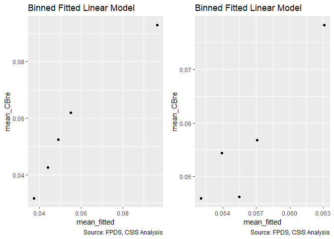

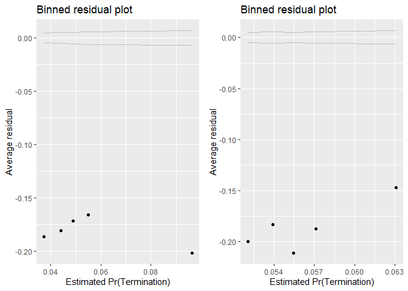

```r
summary_residual_compare(b_CBre03D,b_CBre12A, skip_vif = TRUE)
```

Fully When considering past office volume alone, the relationship was as expected with cost-ceiling breaches. Out of our expectation, the results also showed increasing post office volume would reduce the possibility of exercised options but increase likelihood of having terminations.

#### 12B: Detailed Industry Diveristy

Expectation: More diverse industries of contracts contracting offices handle, the higher complexity they deal with, which would increase the likelihood of having cost ceiling breaches and terminations, and decreasing the likelihood of having options exercised.

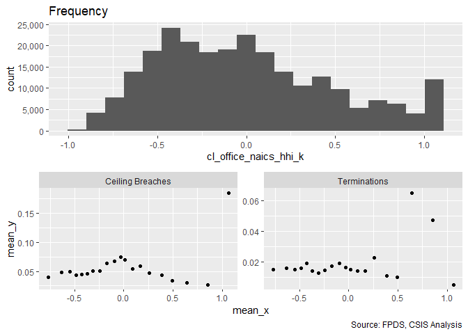

```r
summary_continuous_plot(serv_smp,"cl_office_naics_hhi_k")
```

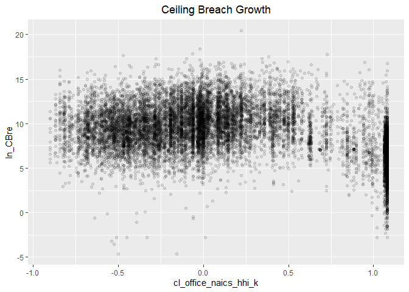

```r
#Scatter Plot
ggplot(serv_smp, aes(x=cl_office_naics_hhi_k, y=ln_CBre)) + geom_point(alpha = 0.1) + ggtitle('Ceiling Breach Growth') + theme(plot.title = element_text(hjust = 0.5))
```

```r
#Model
b_CBre12B <- glm (data=serv_smp,
                 b_CBre ~ cl_office_naics_hhi_k, family=binomial(link="logit"))
display(b_CBre12B)
```

```
## glm(formula = b_CBre ~ cl_office_naics_hhi_k, family = binomial(link = "logit"),
##     data = serv_smp)
##                       coef.est coef.se
## (Intercept)           -2.84     0.01
## cl_office_naics_hhi_k  0.43     0.02
## ---
##   n = 250000, k = 2
##   residual deviance = 107743.7, null deviance = 108365.4 (difference = 621.7)
```

```r
n_CBre12B <- glm(data=serv_smp,
                        ln_CBre ~ cl_office_naics_hhi_k)

display(n_CBre12B)
```

```
## glm(formula = ln_CBre ~ cl_office_naics_hhi_k, data = serv_smp)
##                       coef.est coef.se
## (Intercept)            9.44     0.02
## cl_office_naics_hhi_k -1.71     0.04
## ---
##   n = 15018, k = 2
##   residual deviance = 100625.8, null deviance = 114568.9 (difference = 13943.0)
##   overdispersion parameter = 6.7
##   residual sd is sqrt(overdispersion) = 2.59
```

```r
#Plot residuals versus fitted
stargazer::stargazer(b_CBre12B,

                       n_CBre12B,
                       type="text",
                       digits=2)
```

```
##
## ==================================================
##                           Dependent variable:
##                       ----------------------------
##                           b_CBre        ln_CBre
##                          logistic       normal
##                            (1)            (2)
## --------------------------------------------------
## cl_office_naics_hhi_k    0.43***       -1.71***
##                           (0.02)        (0.04)
##
## Constant                 -2.84***       9.44***
##                           (0.01)        (0.02)
##
## --------------------------------------------------
## Observations             250,000        15,018
## Log Likelihood          -53,871.84    -35,593.94
## Akaike Inf. Crit.       107,747.70     71,191.87
## ==================================================
## Note:                  *p<0.1; **p<0.05; ***p<0.01
```

```r
# summary_residual_compare(b_CBre11A,b_CBre12B, skip_vif = TRUE)
# summary_residual_compare(b_CBre03D,b_CBre12B, skip_vif = TRUE)
```

#### 12C: Cumulative Model

```r
#Frequency Plot for unlogged ceiling


#Model
b_CBre12C <- glm (data=serv_smp,
                 b_CBre ~  cl_US6_avg_sal_lag1Const +
                   cl_CFTE+ c_pPBSC+c_pOffPSC+
                 c_pairHist+cl_pairCA +
                   cl_Ceil + capped_cl_Days+
                   Comp1or5+
                   Veh+
                   PricingUCA+
                   Crisis+
                   cl_def6_HHI_lag1+cl_def6_ratio_lag1+
                   cl_def3_HHI_lag1+cl_def3_ratio_lag1+
                   c_pMarket+
                   cl_OffVol+cl_office_naics_hhi_k , family=binomial(link="logit"))
glmer_examine(b_CBre12C)
```

```
##                              GVIF Df GVIF^(1/(2*Df))
## cl_US6_avg_sal_lag1Const 1.687530  1        1.299050
## cl_CFTE                  1.332134  1        1.154181
## c_pPBSC                  1.499162  1        1.224403
## c_pOffPSC                2.702780  1        1.644013
## c_pairHist               1.380565  1        1.174974
## cl_pairCA                2.303935  1        1.517872
## cl_Ceil                  1.520395  1        1.233043
## capped_cl_Days           1.423689  1        1.193184
## Comp1or5                 1.273862  3        1.041167
## Veh                      1.842504  4        1.079384
## PricingUCA               1.223019  6        1.016918
## Crisis                   1.343221  3        1.050408
## cl_def6_HHI_lag1         2.095171  1        1.447471
## cl_def6_ratio_lag1       1.857510  1        1.362905
## cl_def3_HHI_lag1         1.944070  1        1.394299
## cl_def3_ratio_lag1       2.291367  1        1.513726
## c_pMarket                1.262464  1        1.123594
## cl_OffVol                1.261818  1        1.123307
## cl_office_naics_hhi_k    2.354932  1        1.534579
```

```r
n_CBre12C <- glm(data=serv_smp,
                        ln_CBre ~  cl_US6_avg_sal_lag1Const +
                   cl_CFTE+ c_pPBSC+c_pOffPSC+
                 c_pairHist+cl_pairCA+
                 cl_Ceil + capped_cl_Days+
                 Comp1or5+
                   Veh+
                   PricingUCA+
                   Crisis+
                 cl_def6_HHI_lag1+cl_def6_ratio_lag1+
                 cl_def3_HHI_lag1+cl_def3_ratio_lag1+
                 c_pMarket+
                   cl_OffVol+cl_office_naics_hhi_k)

glmer_examine(n_CBre12C)
```

```
##                              GVIF Df GVIF^(1/(2*Df))
## cl_US6_avg_sal_lag1Const 1.677553  1        1.295204
## cl_CFTE                  1.402218  1        1.184153
## c_pPBSC                  2.403754  1        1.550405
## c_pOffPSC                4.572992  1        2.138456
## c_pairHist               1.436100  1        1.198374
## cl_pairCA                2.915731  1        1.707551
## cl_Ceil                  1.988039  1        1.409979
## capped_cl_Days           1.646363  1        1.283107
## Comp1or5                 1.335003  3        1.049334
## Veh                      2.144287  4        1.100045
## PricingUCA               1.329562  6        1.024021
## Crisis                   1.267360  3        1.040279
## cl_def6_HHI_lag1         2.938676  1        1.714257
## cl_def6_ratio_lag1       1.654931  1        1.286441
## cl_def3_HHI_lag1         2.127966  1        1.458755
## cl_def3_ratio_lag1       2.086393  1        1.444435
## c_pMarket                1.325622  1        1.151357
## cl_OffVol                1.281805  1        1.132168
## cl_office_naics_hhi_k    3.133715  1        1.770230
```

```r
#Plot residuals versus fitted
stargazer::stargazer(b_CBre11B,b_CBre12A,b_CBre12C,

                     n_CBre11B,n_CBre12A,n_CBre12C,
                       type="text",
                       digits=2)
```

```
##
## ================================================================================================
##                                                       Dependent variable:
##                                -----------------------------------------------------------------
##                                             b_CBre                          ln_CBre
##                                            logistic                          normal
##                                   (1)        (2)        (3)        (4)        (5)        (6)
## ------------------------------------------------------------------------------------------------
## cl_US6_avg_sal_lag1Const        -0.10***              -0.07***    0.11**                0.11**
##                                  (0.03)                (0.03)     (0.05)                (0.05)
##
## cl_CFTE                         0.07***               0.08***    0.26***               0.24***
##                                  (0.02)                (0.02)     (0.04)                (0.04)
##
## c_pPBSC                         -0.24***              -0.19***   -0.26***              -0.30***
##                                  (0.02)                (0.02)     (0.04)                (0.04)
##
## c_pOffPSC                       1.04***               1.08***    -0.56***              -0.51***
##                                  (0.02)                (0.02)     (0.04)                (0.04)
##
## c_pairHist                      -0.06***                0.01      0.07*                 -0.02
##                                  (0.02)                (0.02)     (0.04)                (0.04)
##
## cl_pairCA                       0.13***               0.17***    -0.14***               -0.10*
##                                  (0.03)                (0.03)     (0.05)                (0.05)
##
## cl_Ceil                         1.03***               1.06***    2.89***               2.87***
##                                  (0.02)                (0.02)     (0.04)                (0.04)
##
## capped_cl_Days                    0.03                0.06***     0.10**                 0.06
##                                  (0.02)                (0.02)     (0.04)                (0.04)
##
## Comp1or51 offer                 -0.10***              -0.12***    -0.02                 -0.01
##                                  (0.03)                (0.03)     (0.06)                (0.06)
##
## Comp1or52-4 offers              0.29***               0.27***    -0.23***              -0.19***
##                                  (0.02)                (0.02)     (0.04)                (0.04)
##
## Comp1or55+ offers               0.33***               0.33***    -0.14***              -0.13***
##                                  (0.03)                (0.03)     (0.04)                (0.04)
```

[output cut: 55 more lines]

```
## cl_OffVol                                  -0.19***   -0.28***              1.30***    0.34***
##                                             (0.01)     (0.02)                (0.04)     (0.03)
##
## cl_office_naics_hhi_k                                 -0.16***                          -0.09*
##                                                        (0.03)                           (0.05)
##
## Constant                        -2.97***   -2.82***   -2.96***   8.72***    9.33***    8.71***
##                                  (0.02)     (0.01)     (0.02)     (0.04)     (0.02)     (0.04)
##
## ------------------------------------------------------------------------------------------------
## Observations                    250,000    250,000    250,000     15,018     15,018     15,018
## Log Likelihood                 -50,316.53 -54,107.46 -50,181.98 -30,145.37 -36,088.22 -30,079.98
## Akaike Inf. Crit.              100,693.10 108,218.90 100,427.90 60,350.75  72,180.43  60,223.97
## ================================================================================================
## Note:                                                                *p<0.1; **p<0.05; ***p<0.01
```

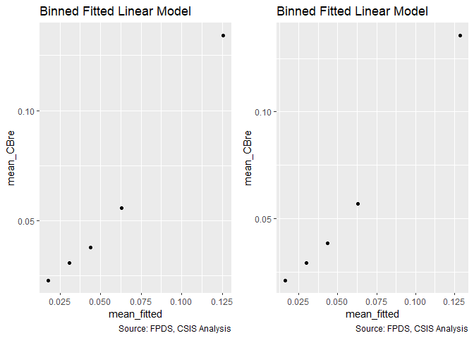

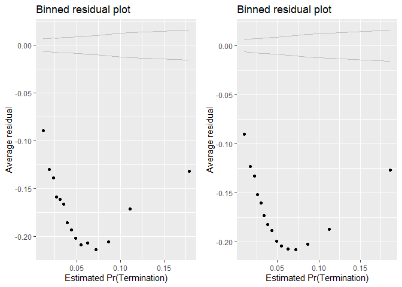

```
## [[1]]
##        model deviance null.deviance difference
## 1 model1_old   101028      108365.4   7337.379
## 2 model1_new   100364      108365.4   8001.405
##
## [[2]]
##                              GVIF Df GVIF^(1/(2*Df))
## cl_US6_avg_sal_lag1Const 1.687530  1        1.299050
## cl_CFTE                  1.332134  1        1.154181
## c_pPBSC                  1.499162  1        1.224403
## c_pOffPSC                2.702780  1        1.644013
## c_pairHist               1.380565  1        1.174974
## cl_pairCA                2.303935  1        1.517872
## cl_Ceil                  1.520395  1        1.233043
## capped_cl_Days           1.423689  1        1.193184
## Comp1or5                 1.273862  3        1.041167
## Veh                      1.842504  4        1.079384
## PricingUCA               1.223019  6        1.016918
## Crisis                   1.343221  3        1.050408
## cl_def6_HHI_lag1         2.095171  1        1.447471
## cl_def6_ratio_lag1       1.857510  1        1.362905
## cl_def3_HHI_lag1         1.944070  1        1.394299
## cl_def3_ratio_lag1       2.291367  1        1.513726
## c_pMarket                1.262464  1        1.123594
## cl_OffVol                1.261818  1        1.123307
## cl_office_naics_hhi_k    2.354932  1        1.534579
```

```r
summary_residual_compare(b_CBre10D,b_CBre12C)
```

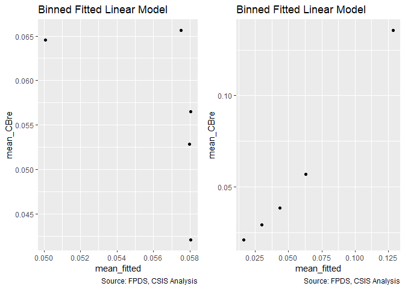

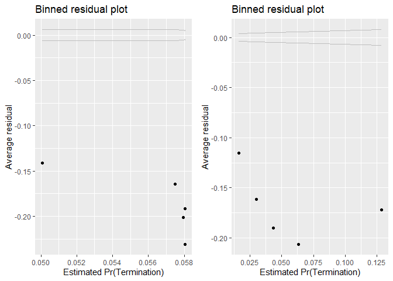

```
## [[1]]
##        model deviance null.deviance difference
## 1 model1_old   108228      108365.4    137.344
## 2 model1_new   100364      108365.4   8001.405
##
## [[2]]
##                              GVIF Df GVIF^(1/(2*Df))
## cl_US6_avg_sal_lag1Const 1.687530  1        1.299050
## cl_CFTE                  1.332134  1        1.154181
## c_pPBSC                  1.499162  1        1.224403
## c_pOffPSC                2.702780  1        1.644013
## c_pairHist               1.380565  1        1.174974
## cl_pairCA                2.303935  1        1.517872
## cl_Ceil                  1.520395  1        1.233043
## capped_cl_Days           1.423689  1        1.193184
## Comp1or5                 1.273862  3        1.041167
## Veh                      1.842504  4        1.079384
## PricingUCA               1.223019  6        1.016918
## Crisis                   1.343221  3        1.050408
## cl_def6_HHI_lag1         2.095171  1        1.447471
## cl_def6_ratio_lag1       1.857510  1        1.362905
## cl_def3_HHI_lag1         1.944070  1        1.394299
## cl_def3_ratio_lag1       2.291367  1        1.513726
## c_pMarket                1.262464  1        1.123594
## cl_OffVol                1.261818  1        1.123307
## cl_office_naics_hhi_k    2.354932  1        1.534579
```

```r
summary_residual_compare(b_CBre11A,b_CBre12C)
```